# emir kuten's assignment

```r
student_id <-  2023301345
library(tidyverse)
library(data.table)
library(broom) # for tidy statistical summaries
library(caret) # for regression performance measures
library(psych) # for pairwise comparisons
library(car) # for multicollinearity
library(moments) # for higher moments

library(PearsonDS) # for Pearson distribution
library(rethinking) # for LKJ distribution
set.seed(student_id)
nvar <- 6
sampsize <- 1e3
etax <- 1e-3
train_ratio <- 0.7
matx <- rlkjcorr(1, nvar, etax)
sampx <- rmvnorm(1e3, sigma = matx)
sampx <- pnorm(sampx)
means <- rnorm(nvar)
vars <- rexp(nvar, 1)
kurts <- rexp(nvar, 1) + 3
skews <- (rbeta(nvar, 3, 3) - 0.5)*2
colnamesx <- paste(sample(words, nvar + 1), "1", sep = "")
sampx_dt <- as.data.table(sampx)
sampx_dt <- as.data.table(mapply(function(x, a, b, c, d) qpearson(x, moments = c(a, b, c, d)), sampx_dt,
                                 means, vars, skews, kurts))
paramst <- as.matrix(runif(nvar, -5, 5))
errx <- as.matrix(rnorm(sampsize, 0, sqrt(rexp(1, 0.1))))
responsex <- as.matrix(sampx_dt) %*% paramst + errx
sampx_dt <- cbind(responsex, sampx_dt)
setnames(sampx_dt, colnamesx)
train_indices <- sampx_dt[,sample(.N * train_ratio)]
train_data <- sampx_dt[train_indices]
test_data <- sampx_dt[-train_indices]
normlz <- function(x)
{
    meanr <- mean(x, na.rm = T)
    varr <- var(x, na.rm = T)
    skewr <- skewness(x, na.rm = T)
    kurtr <- kurtosis(x, na.rm = T)
    normlx <- qnorm(ppearson(x, moments = c(meanr, varr, skewr, kurtr)))
    ifelse(is.infinite(normlx), NA, normlx)
    }
```

```
rethinking (Version 2.13.2)
```

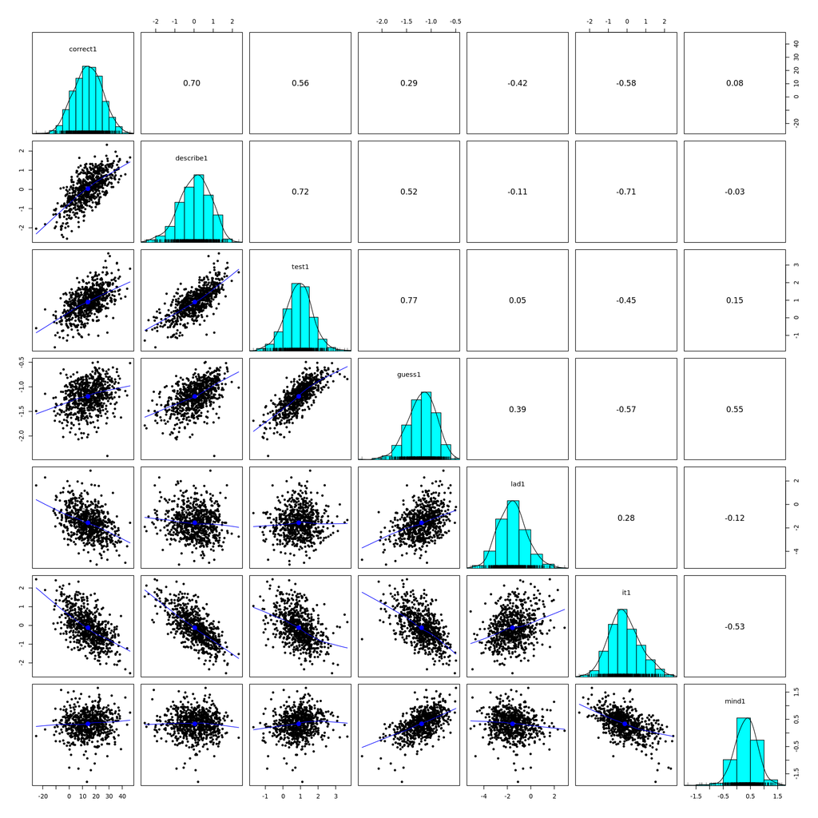

```r
options(repr.plot.width = 15, repr.plot.height = 15)
pairs.panels(train_data)
```

```r
model1 <- lm(correct1 ~ describe1 + test1 + guess1 + lad1 + it1 + mind1, train_data)
```

```r
summary(model1)
```

```
Call:
lm(formula = correct1 ~ describe1 + test1 + guess1 + lad1 + it1 +
    mind1, data = train_data)

Residuals:
     Min       1Q   Median       3Q      Max
-17.1123  -4.1821   0.0043   4.2973  18.9832

Coefficients:
            Estimate Std. Error t value Pr(>|t|)
(Intercept)  -2.3802    12.8452  -0.185   0.8530
describe1     5.3324     0.9231   5.777 1.15e-08 ***
test1         4.8213     2.2247   2.167   0.0306 *
guess1       -6.3916     9.7371  -0.656   0.5118
lad1         -2.5265     1.1017  -2.293   0.0221 *
it1          -1.8609     1.1142  -1.670   0.0953 .
mind1         0.5006     2.8199   0.178   0.8591
---
Signif. codes:  0 ‘***’ 0.001 ‘**’ 0.01 ‘*’ 0.05 ‘.’ 0.1 ‘ ’ 1

Residual standard error: 6.464 on 693 degrees of freedom
Multiple R-squared:  0.6316,	Adjusted R-squared:  0.6284
F-statistic:   198 on 6 and 693 DF,  p-value: < 2.2e-16
```

R squared value is 0.6316 which means it is not high (0.6316<0.80). That is, our decision variable can be explained by approximately 63% of our variables. Also we should reject the null hypothesis because p value (2.2e-16) is smaller than 0.05. Hence, my model is statistically significant. Describe1,test1,lad1 are significant because they are smaller than 5. Intercept value is -2.3802 which means when we set other variables to zero we get response variable's value by looking at intercept value. Describe1, test1 and mind1 have positive, guess1,lad1,it1 have negative sign.

```r
tidy(model1)
```

A tibble: 7 × 5

| term <chr> | estimate <dbl> | std.error <dbl> | statistic <dbl> | p.value <dbl> |
| --- | --- | --- | --- | --- |
| (Intercept) | -2.3801827 | 12.8451961 | -0.1852975 | 8.530499e-01 |
| describe1 | 5.3323521 | 0.9230669 | 5.7767776 | 1.150259e-08 |
| test1 | 4.8212852 | 2.2247164 | 2.1671459 | 3.056367e-02 |
| guess1 | -6.3915748 | 9.7370838 | -0.6564157 | 5.117746e-01 |
| lad1 | -2.5265198 | 1.1017309 | -2.2932278 | 2.213345e-02 |
| it1 | -1.8609207 | 1.1142307 | -1.6701395 | 9.534333e-02 |
| mind1 | 0.5006098 | 2.8198618 | 0.1775299 | 8.591441e-01 |

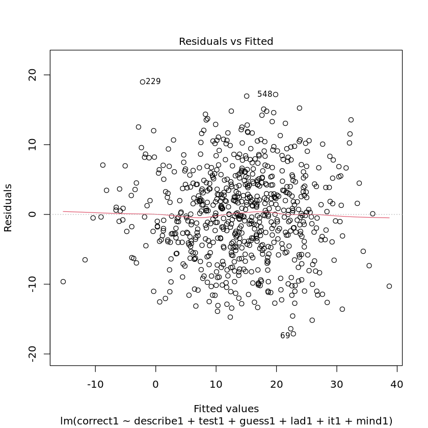

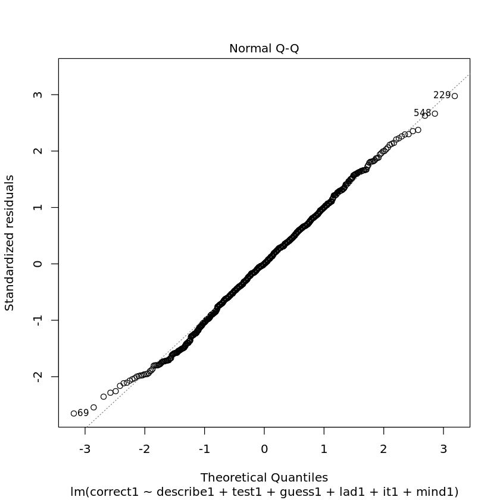

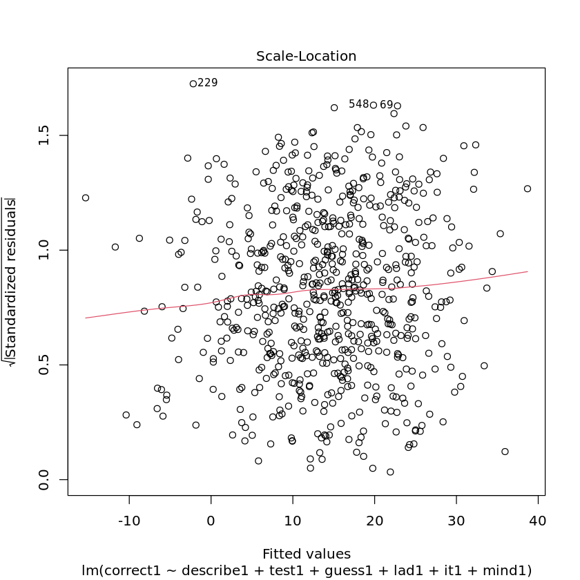

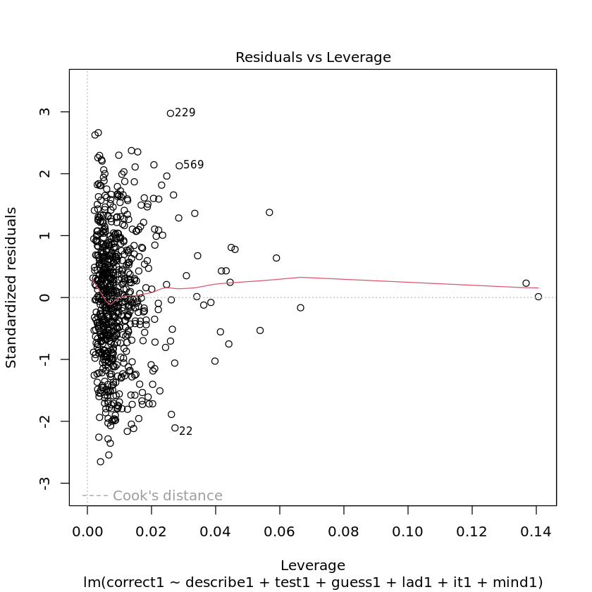

```r
options(repr.plot.width = 7, repr.plot.height = 7)
plot(model1)
```

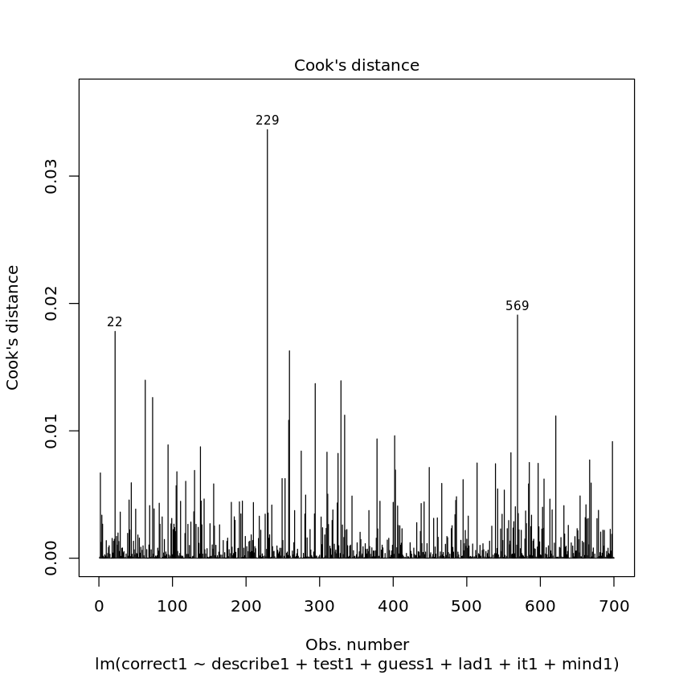

```r
plot(model1, which = 4)
```

```r
cooksd <- cooks.distance(model1)
summary(cooksd)
```

```
     Min.   1st Qu.    Median      Mean   3rd Qu.      Max.
0.0000000 0.0001031 0.0004676 0.0014461 0.0016160 0.0336432
```

```r
round(head(sort(cooksd, decreasing = T), 10), 4)
```

**229**

0.0336

**569**

0.0191

**22**

0.0178

**259**

0.0163

**63**

0.014

**329**

0.0139

**294**

0.0137

**73**

0.0126

**334**

0.0112

**621**

0.0112

```r
shapiro.test(model1$residuals)
```

```
	Shapiro-Wilk normality test

data:  model1$residuals
W = 0.99679, p-value = 0.1757
```

Our P value is 0.1757 which is bigger than 0.05 hence we do not violate normality.

```r
model2 <- lm(correct1 ~ describe1 + test1 +lad1  +it1 + mind1, train_data)
vif(model2)
```

**describe1**

8.96329296143962

**test1**

3.08583872926067

**lad1**

1.14651866431769

**it1**

7.52084650675307

**mind1**

3.73810538405894

Describe1 has the highest vif value. Also it1 and describe 1 has vif value higher than 5. Our model shows signs of high multicollinearity.

The variables it1 (VIF = 7.52) and describe1 (VIF = 8.96) have VIF scores are above the common threshold of 5. Hence, they are highly correlated with other predictors in our model.